# Chignik Early Run Modeling

Sarah Power

September 4, 2018

## Chignik Early Run Timing

For over a decade genetic samples of sockeye (Oncorhynchus nerka) have been collected at the Chignik weir which has distinguished the early run, which mostly spawns in Black Lake to be distinguished form later runs. The majority of these later runs spawn in Chignik Lake. Currently these stocks are managed separately. The processing of genetics samples is expensive, and so alternative methods for distinguishing between the stocks are being examined. In the years prior to genetic assignment July 4th was used as a cut off date between the early and late runs with the understanding that some early run fish arrive later and some later run fish arrive earlier.

In this analysis we will examine the runtiming distributions to determine how well we can discern the early run stocks from the later ones on runtiming alone. We will compare this to the runtiming distributions that are determined with the additional aid of genetics to see how viable this method might be.

Currently the run consists of the escapement as captured by the weir, as well as catch from various districts, some of which are quite far away. The genetic assignment at the weir is attributed to catch from nearer to farther districts with the understanding that the genetic assignment found at the weir today, should be attributed to what was caught in the lagoon yesterday, and caught in the Chicknig area outside of that two days ago, and beyond that various lag times as determined by other literature.

Our method of modeling is to use maximum likelihood methods including the EM algorithm and a Newton-type algorithm to parse out various distributions using the mixdist package in R.

Creelman (2011) hypothesized that the early run and later runs are comprised of various smaller runs with their own runtiming and run locations.She found that run timing played an important role in genetic variation, which makes distinguishing run based on runtiming a possibility. She grouped collections into four genetic groups: Black Lake, Chignik Lake, Chignik Lake October, and Chingnik River. Looking at the distributions across the years there appears to be three modes. Noting that data from the weir is collected from about late may until the end of September, and that Creelman noted an October Chignik Lake run the assumption we will take is that there is a biological reason for three modes to be presented in the data..

The data from the weir is collected from about late may until the end of September. Looking at the distributions there appears to be three modes. The assumption we will take is that there are three modes presented in the data, that maybe there would be a fourth if data were collected into October. In initial investigations Normal and Weibull distributions were fit, also certain constraints were considered inorder to find the best fit. Those constraints included equal standard errors; means equally spaced, and having the mean or standard error of the early distribution fixed to median value of the corresponding mean or standared error that used genetic information to determine a runtiming distribution.

With this model for 8 of the 11 years early run counts using runtiming alone were with 10% of the counts using additional genetic information. The three best years included 2010, 2013, and 2014, where early run counts using runtiming information alone differed by no more than 3% of the counts using additional genetic information.

Once this model was determined to be the best the run counts of each of the years were examined. For 8 of the 11 years Between 2006 and 2017 early run counts using runtiming alone were with 10% of the counts using additional genetic information. The three best years included 2010, 2013, and 2014, where early run counts using runtiming information alone differed by no more than 3% of the counts using additional genetic information.

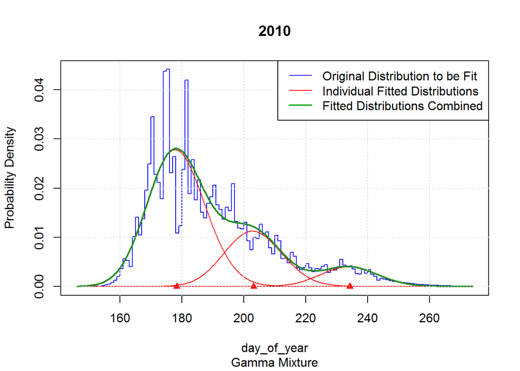

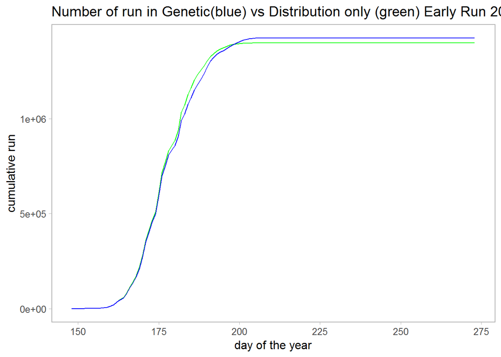

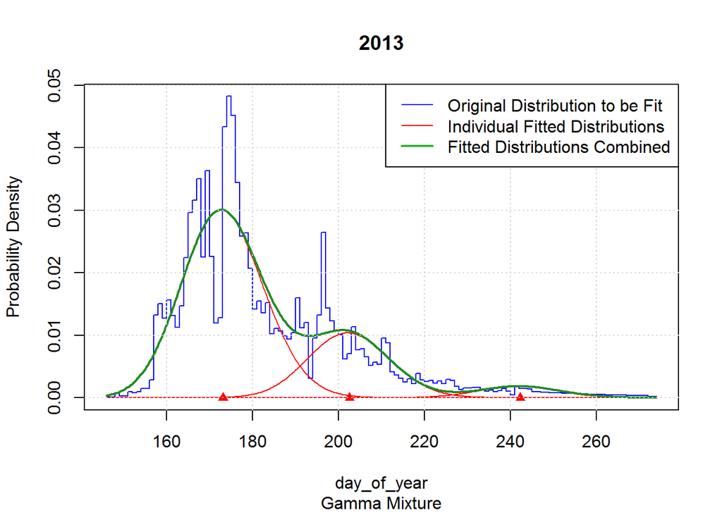

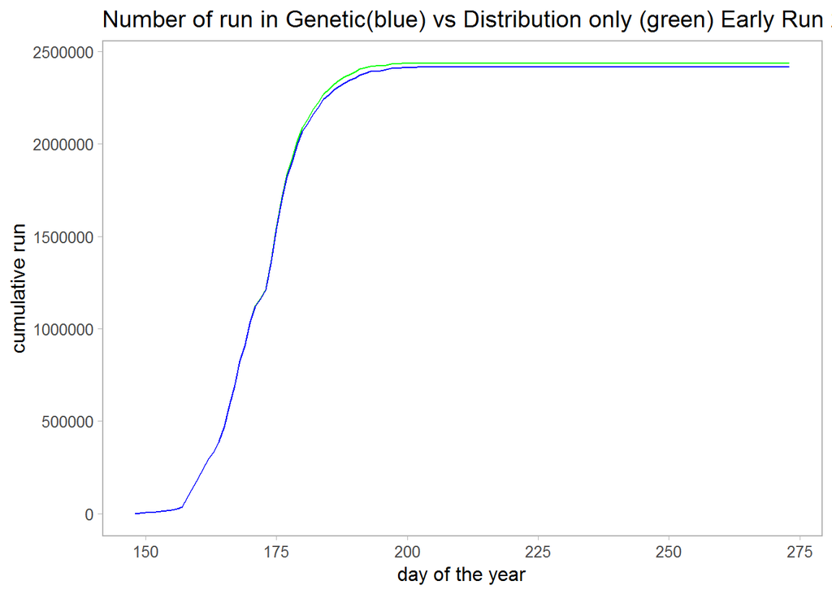

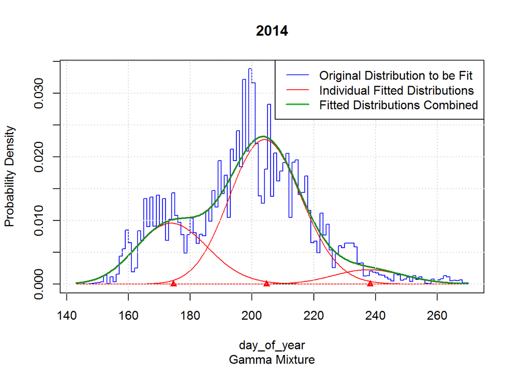

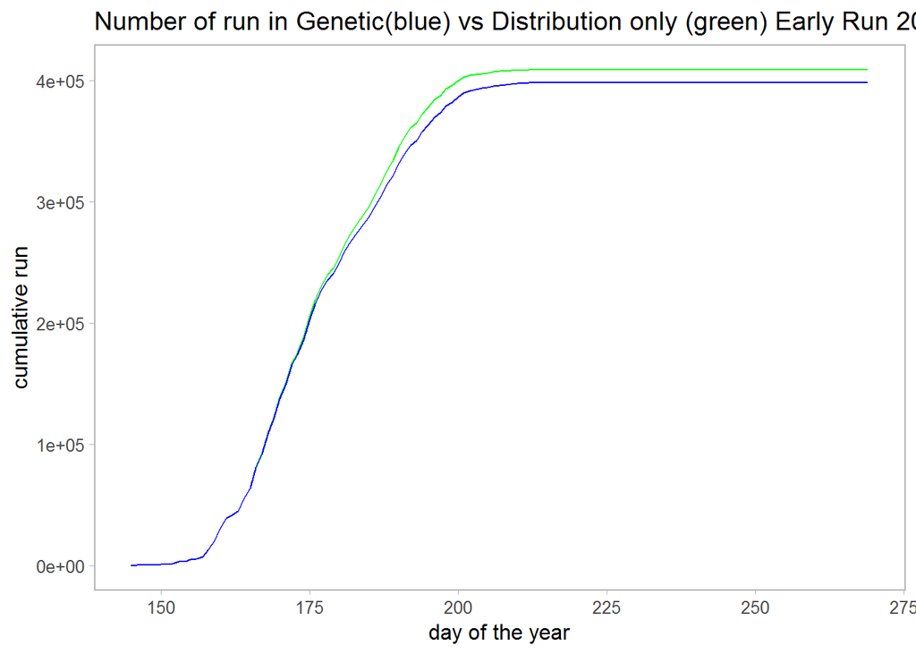

The three years that runtiming distributions were off by more than 10% included 2008, which overestimated the early run by 27%, 2015 where it underestimated the early run by 25% and 2012 where is over estimated the run by a whopping 67%.

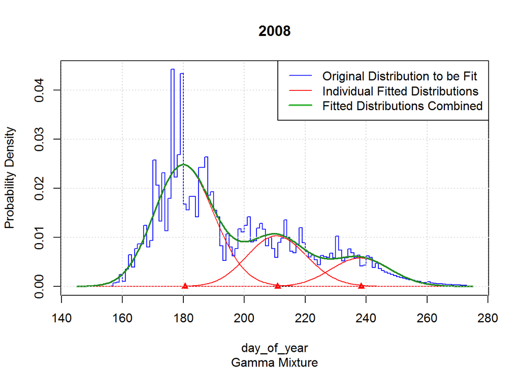

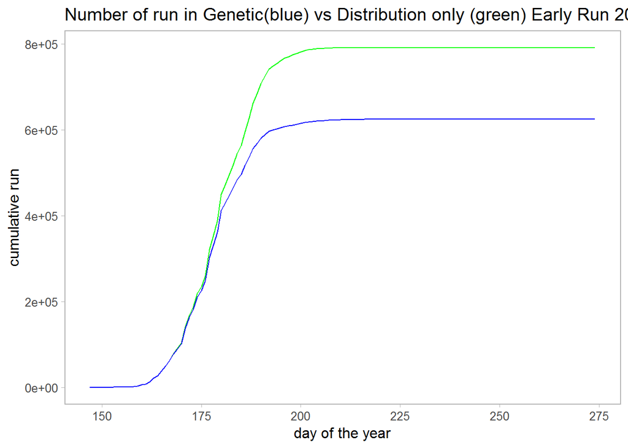

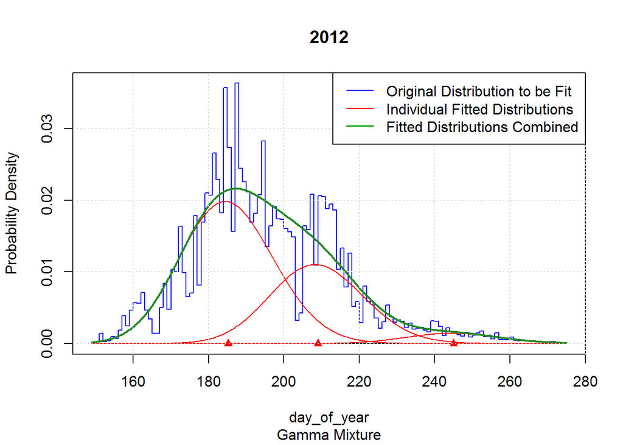

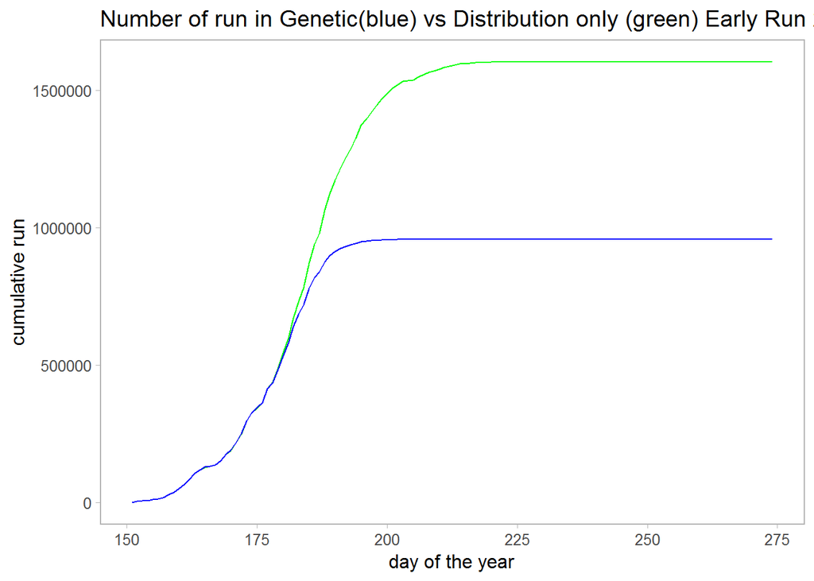

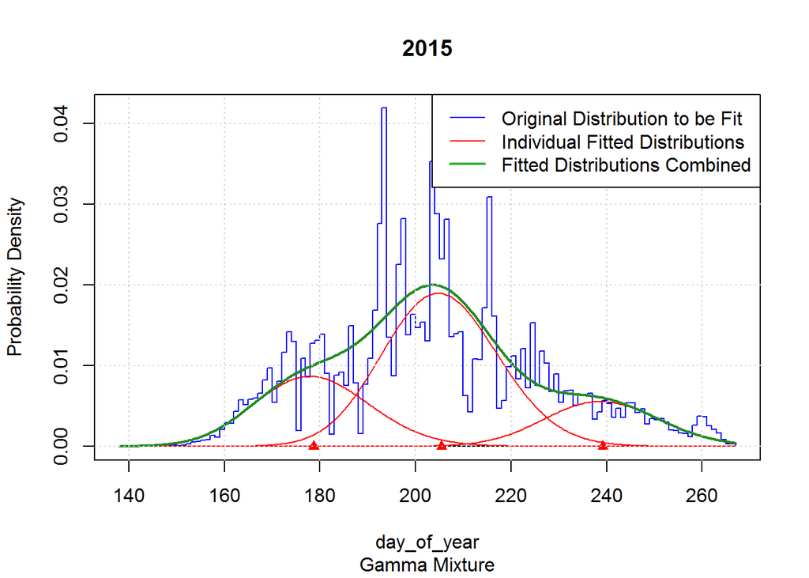

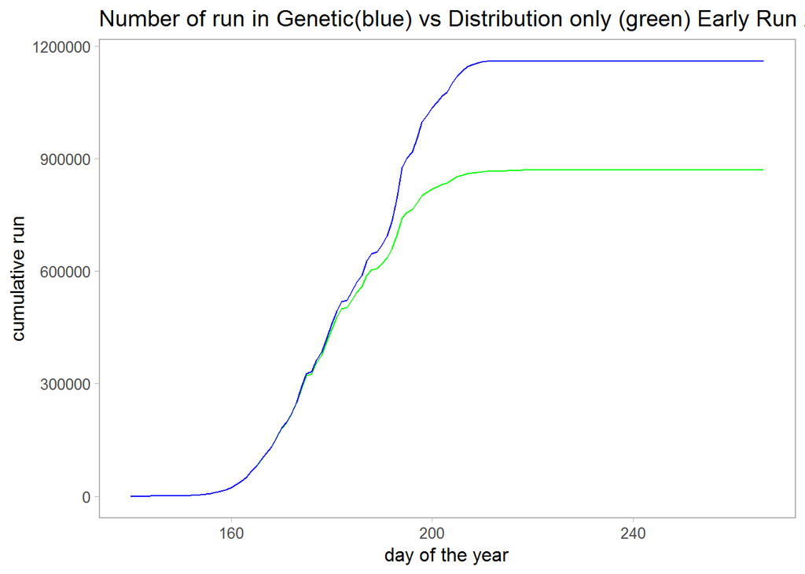

It was suggested by Heather Finkle that using catch information from farther flung districts might add noise to the distributions since those districts surely would contain harvest from non-Chignik stocks. The analysis was reexamined this time using only harvests that were a day or twos fish-swim away.

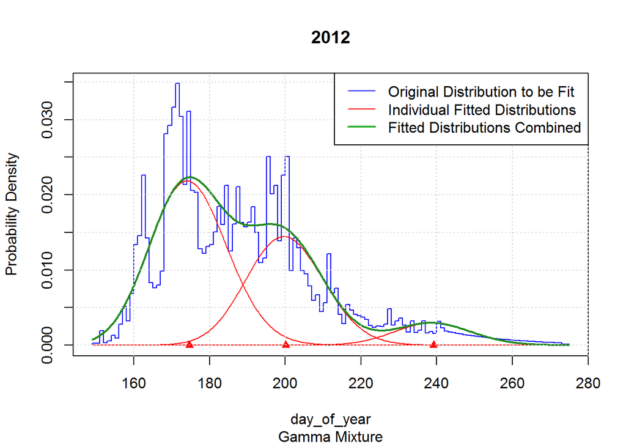

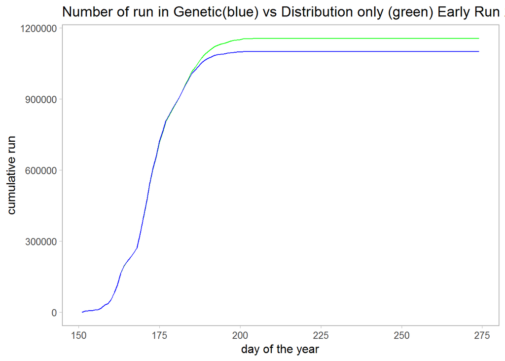

Future analysis could include examining if there are any factors that explain why 2008 and 2015 preformed poorly with the model. Initial investigations note that the mean day-of-year for early runtiming is shifted to the right 3 days for 2008 and 2 days for 2015, indicating that the estimated distribution is pulled to the right of what it would be using additional genetic information. Biologists note that harvest and runsize may have been different. Also examining time and area harvest to include in runtime estimates may improve the model.

It is important to note that the definition of the run, at least in terms of this model, changed from what is currently used. Harvest farther from the Chignik area were excluded. If this model, or one like it were used in the future it should be determined if the run estimates for this model are only to distinguish the percentage of early vs late run stocks (recommended for near term), or if the methods behind estimates of harvest should be reexamined, (recommended for the future).

Below are the graphs for all the years using model with the more conservative data set:

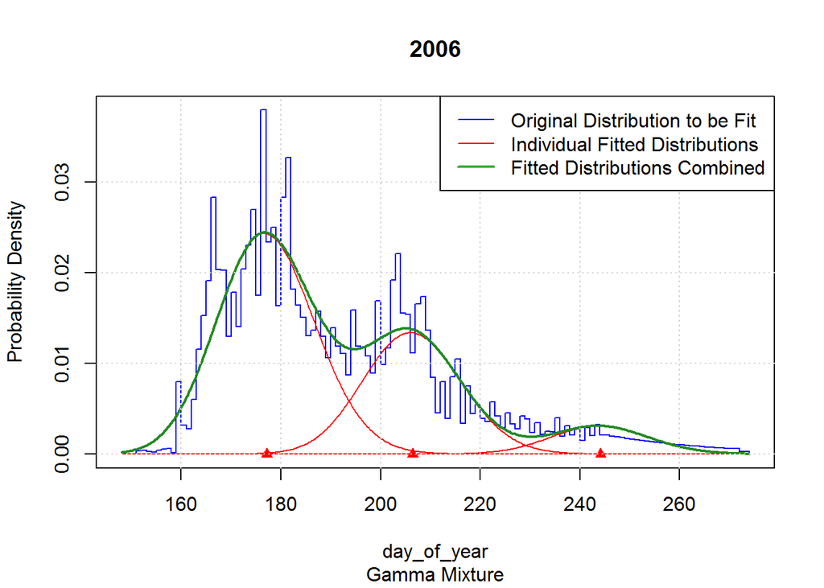

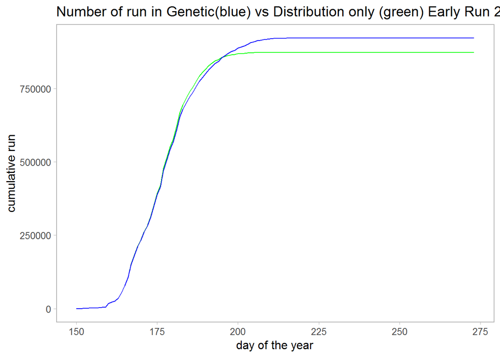

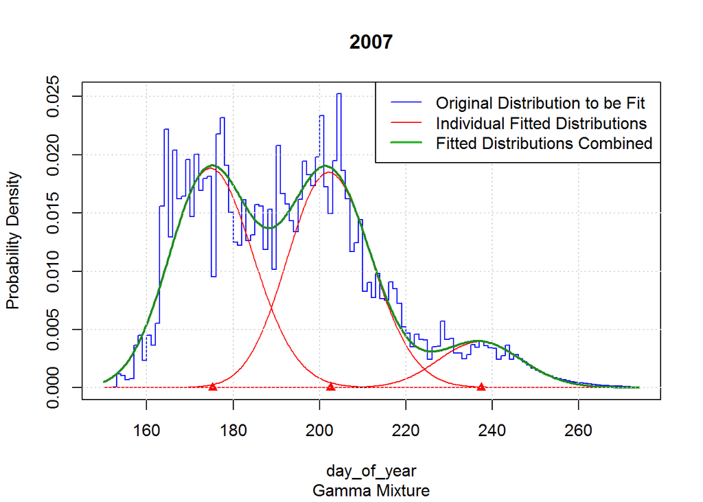

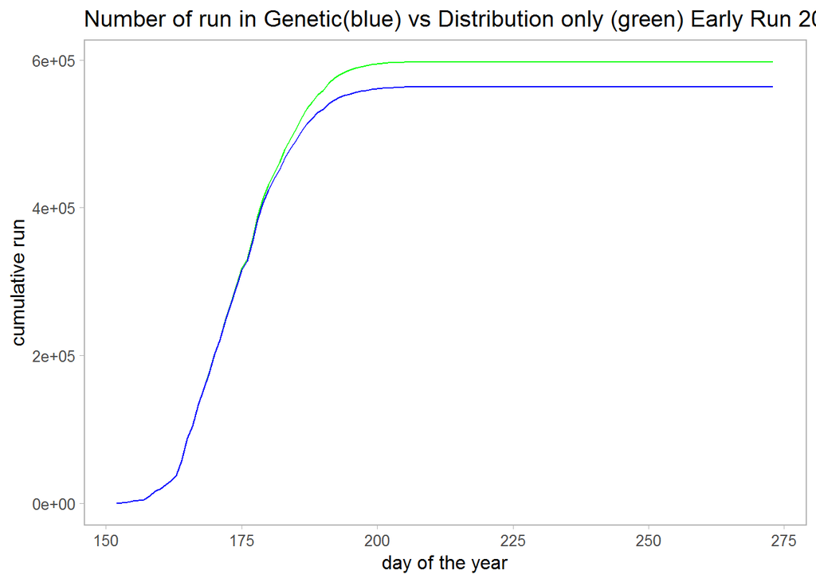

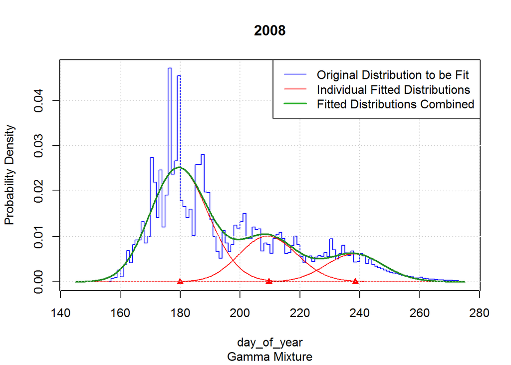

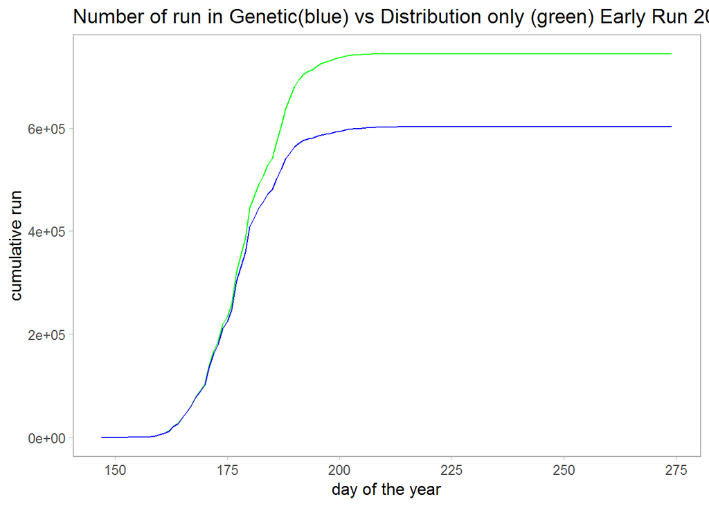

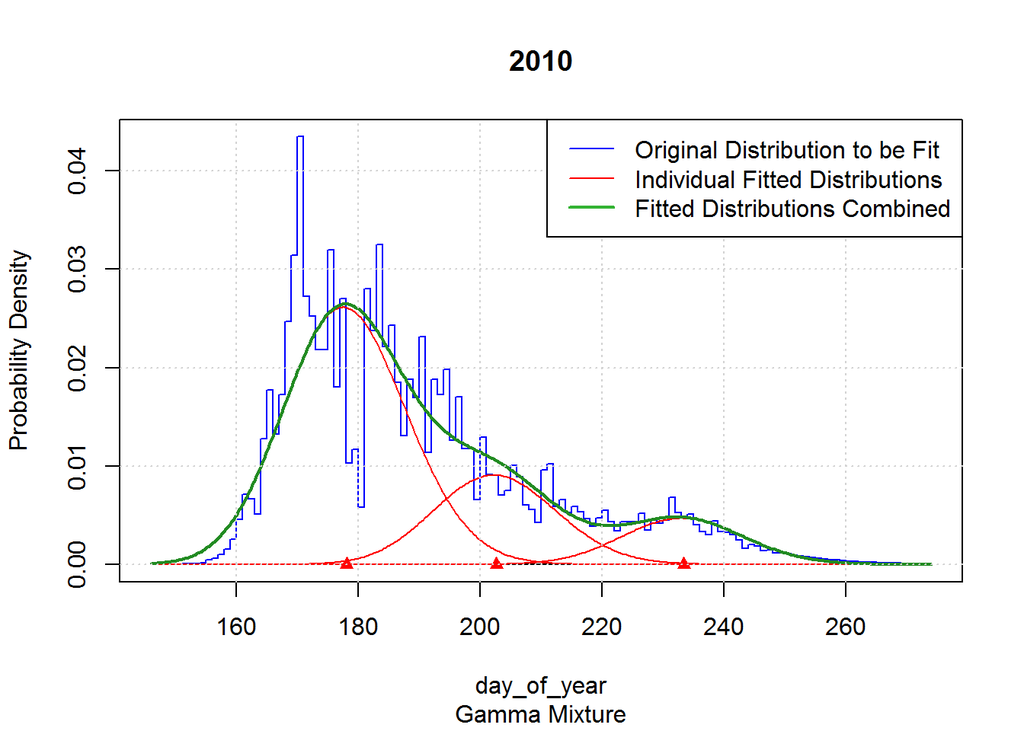

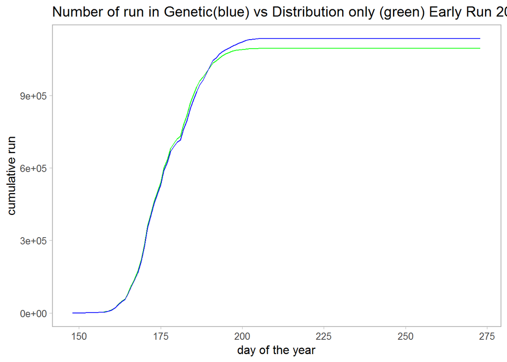

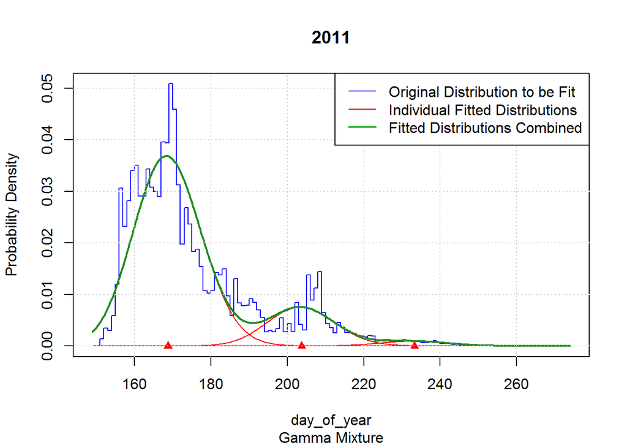

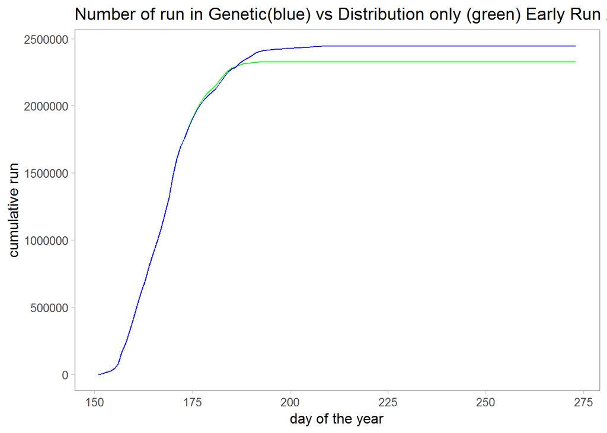

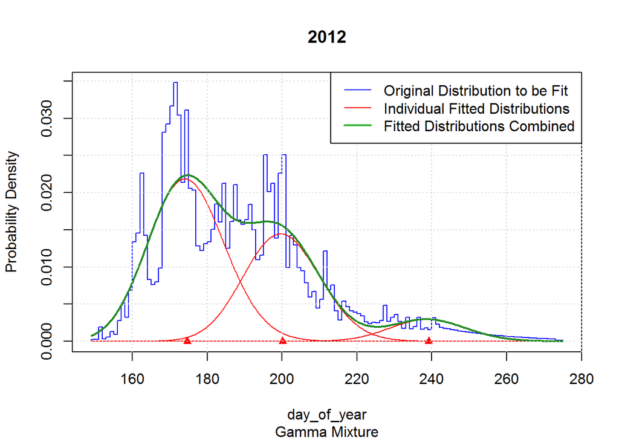

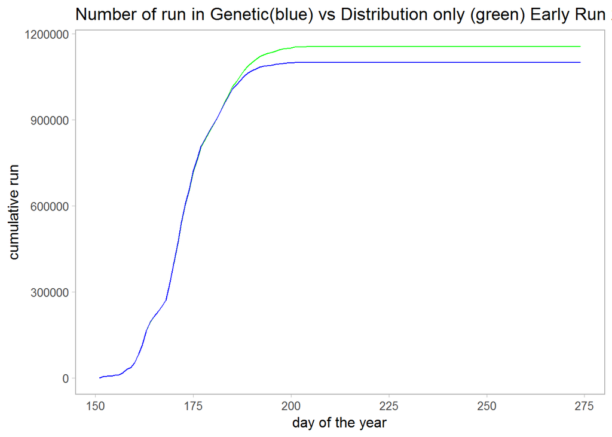

[10 more figures not shown]